# Biostat 212a Homework 2

Due Feb 6, 2024 @ 11:59PM

Author

Yuhui Wang, UID: 606332401

Published

February 6, 2024

## 1 ISL Exercise 4.8.1 (10pts)

> Using a little bit of algebra, prove that (4.2) is equivalent to (4.3). In other words, the logistic function representation and logit representation for the logistic regression model are equivalent.

**Answer:**

To answer that question, we are actually trying to prove that

(4.2)
$$p(X) = \frac{e^{\beta_0 + \beta_1X}}{1 + e^{\beta_0 + \beta_1X}}$$

is equivalent to

(4.3)
$$\frac{p(X)}{1-p(X)} = e^{\beta_0 + \beta_1X}$$

To prove that, firstly, assume $x = e^{\beta_0 + \beta_1X}$ Then according to equation (4.2), we have:
$$\begin{align}
\frac{p(X)}{1-p(X)} &= \frac{\frac{x}{1 + x}}
{1 - \frac{x}{1 + x}} \\
&= \frac{\frac{x}{1 + x}}
{\frac{1}{1 + x}} \\
&= x
\end{align}$$
After substituting $x$ with $e^{\beta_0 + \beta_1X}$, we have equation (4.3).

## 2 ISL Exercise 4.8.6 (10pts)

> Suppose we collect data for a group of students in a statistics class with variables $X_1 =$ hours studied, $X_2 =$ undergrad GPA, and $Y =$ receive an A. We fit a logistic regression and produce estimated coefficient, $\hat\beta_0 = -6$, $\hat\beta_1 = 0.05$, $\hat\beta_2 = 1$.
> 1. Estimate the probability that a student who studies for 40h and has an undergrad GPA of 3.5 gets an A in the class.

**Answer:**

The logistic model for this situation is:

$$\log\left(\frac{p(X)}{1-p(X)}\right) = -6 + 0.05X_1 + X_2$$

Converting this to a probability gives:

$$p(X) = \frac{e^{-6 + 0.05X_1 + X_2}}{1 + e^{-6 + 0.05X_1 + X_2}}$$

when $X_1 = 40$ and $X_2 = 3.5$,

```r
exp(-6 + 0.05 * 40 + 3.5) / (1 + exp(-6 + 0.05 * 40 + 3.5))
```

```
[1] 0.3775407
```

$p(X) = 0.38$

> 2. How many hours would the student in part (a) need to study to have a 50% chance of getting an A in the class?

**Answer:**

Given the GPA ($X_2$) is fixed, we can solve for $X_1$ where $p(X) = 0.5$. According to the equation above, we have: $0 = −6 + 0.05X_1 + 3.5$, After solving this equation, we have $X_1 = 50$ hours.

## 3 ISL Exercise 4.8.9 (10pts)

> This problem has to do with *odds*.
> 1. On average, what fraction of people with an odds of 0.37 of defaulting on their credit card payment will in fact default?

**Answer:** As odds is defined: $p/(1-p)$, we have:

$$\frac{p(x)}{1 - p(x)} = 0.37$$

therefore,

$$p(x) = \frac{0.37}{1 + 0.37} = 0.27$$
The fraction is 0.27.

> 2. Suppose that an individual has a 16% chance of defaulting on her credit card payment. What are the odds that she will default?

**Answer:**

According to the equation,
$$Odds = \frac{0.16}{1 - 0.16} = 0.19$$
The odds is 0.19.

## 4 ISL Exercise 4.8.13 (a)-(i) (50pts)

> This question should be answered using the `Weekly` data set, which is part of the `ISLR2` package. This data is similar in nature to the `Smarket` data from this chapter’s lab, except that it contains 1,089 weekly returns for 21 years, from the beginning of 1990 to the end of 2010.
> 1. Produce some numerical and graphical summaries of the `Weekly` data. Do there appear to be any patterns?

**Answer:**

```r
library(MASS)
library(class)
library(tidyverse)
library(corrplot)
library(ISLR2)
library(e1071)
```

```r
summary(Weekly)
```

```
      Year           Lag1               Lag2               Lag3
 Min.   :1990   Min.   :-18.1950   Min.   :-18.1950   Min.   :-18.1950
 1st Qu.:1995   1st Qu.: -1.1540   1st Qu.: -1.1540   1st Qu.: -1.1580
 Median :2000   Median :  0.2410   Median :  0.2410   Median :  0.2410
 Mean   :2000   Mean   :  0.1506   Mean   :  0.1511   Mean   :  0.1472
 3rd Qu.:2005   3rd Qu.:  1.4050   3rd Qu.:  1.4090   3rd Qu.:  1.4090
 Max.   :2010   Max.   : 12.0260   Max.   : 12.0260   Max.   : 12.0260
      Lag4               Lag5              Volume            Today
 Min.   :-18.1950   Min.   :-18.1950   Min.   :0.08747   Min.   :-18.1950
 1st Qu.: -1.1580   1st Qu.: -1.1660   1st Qu.:0.33202   1st Qu.: -1.1540
 Median :  0.2380   Median :  0.2340   Median :1.00268   Median :  0.2410
 Mean   :  0.1458   Mean   :  0.1399   Mean   :1.57462   Mean   :  0.1499
 3rd Qu.:  1.4090   3rd Qu.:  1.4050   3rd Qu.:2.05373   3rd Qu.:  1.4050
 Max.   : 12.0260   Max.   : 12.0260   Max.   :9.32821   Max.   : 12.0260
 Direction
 Down:484
 Up  :605
```

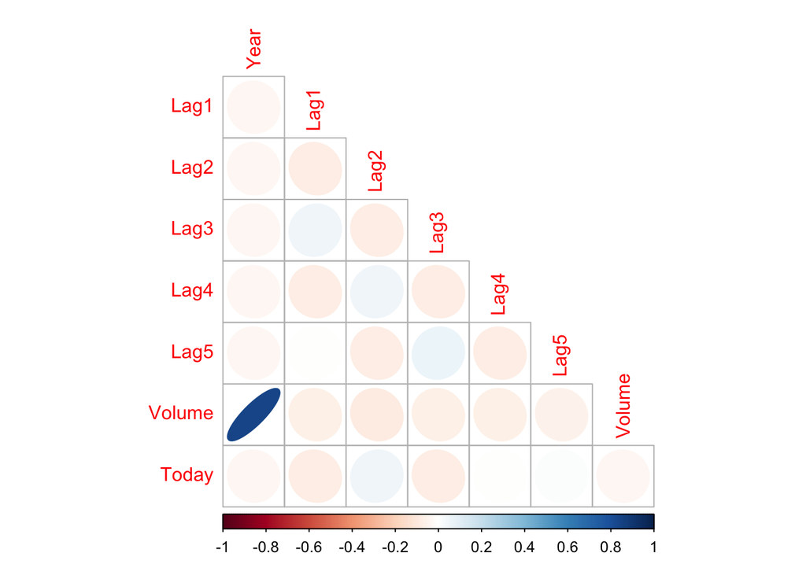

```r
corrplot(cor(Weekly[, -9]), type = "lower", diag = FALSE, method = "ellipse")
```

From the graph, we can see that variable `Volume` is strongly positively correlated with variable `Year`. Other variables’ correlations are week.

> 2. Use the full data set to perform a logistic regression with `Direction` as the response and the five lag variables plus `Volume` as predictors. Use the summary function to print the results. Do any of the predictors appear to be statistically significant? If so, which ones?

**Answer:**

```r
logistic_fit <- glm(
  Direction ~ Lag1 + Lag2 + Lag3 + Lag4 + Lag5 + Volume,
  data = Weekly,
  family = binomial
)
summary(logistic_fit)
```

```
Call:
glm(formula = Direction ~ Lag1 + Lag2 + Lag3 + Lag4 + Lag5 +
    Volume, family = binomial, data = Weekly)

Coefficients:
            Estimate Std. Error z value Pr(>|z|)
(Intercept)  0.26686    0.08593   3.106   0.0019 **
Lag1        -0.04127    0.02641  -1.563   0.1181
Lag2         0.05844    0.02686   2.175   0.0296 *
Lag3        -0.01606    0.02666  -0.602   0.5469
Lag4        -0.02779    0.02646  -1.050   0.2937
Lag5        -0.01447    0.02638  -0.549   0.5833
Volume      -0.02274    0.03690  -0.616   0.5377
---
Signif. codes:  0 '***' 0.001 '**' 0.01 '*' 0.05 '.' 0.1 ' ' 1

(Dispersion parameter for binomial family taken to be 1)

    Null deviance: 1496.2  on 1088  degrees of freedom
Residual deviance: 1486.4  on 1082  degrees of freedom
AIC: 1500.4

Number of Fisher Scoring iterations: 4
```

From the summary, we know that Lag2 is significant.

> 3. Compute the confusion matrix and overall fraction of correct predictions. Explain what the confusion matrix is telling you about the types of mistakes made by logistic regression.

**Answer:**

```r
contrasts(Weekly$Direction)
```

```
     Up
Down  0
Up    1
```

```r
pred <- predict(logistic_fit, type = "response") > 0.5
t <- table(ifelse(pred, "Up (pred)", "Down (pred)"), Weekly$Direction)
t
```

```
              Down  Up
  Down (pred)   54  48
  Up (pred)    430 557
```

```r
sum(diag(t)) / sum(t)
```

```
[1] 0.5610652
```

The overall fraction of correct predictions is 0.56. The logistic regression model predicts most of upwards direction correctly. However, it predicts downwards direction poorly.

> 4. Now fit the logistic regression model using a training data period from 1990 to 2008, with `Lag2` as the only predictor. Compute the confusion matrix and the overall fraction of correct predictions for the held out data (that is, the data from 2009 and 2010).

**Answer:**

```r
training_data <- Weekly$Year < 2009
head(training_data)
```

```
[1] TRUE TRUE TRUE TRUE TRUE TRUE
```

```r
lag2_fit <- glm(Direction ~ Lag2, data = Weekly[training_data, ], family = binomial)
```

```r
pred <- predict(lag2_fit, Weekly[!training_data, ], type = "response") > 0.5
```

```r
t <- table(ifelse(pred, "Up (pred)", "Down (pred)"), Weekly[!training_data, ]$Direction)
print(t)
```

```
              Down Up
  Down (pred)    9  5
  Up (pred)     34 56
```

```r
sum(diag(t)) / sum(t)
```

```
[1] 0.625
```

The overall fraction of correct predictions is 0.625.

> 5. Repeat (d) using LDA.

**Answer:**

```r
lda_fit <- lda(Direction ~ Lag2, data = Weekly[training_data, ])
```

```r
pred <- predict(lda_fit, Weekly[!training_data, ], type = "response")$class
```

```r
t <- table(pred, Weekly[!training_data, ]$Direction)
t
```

```
pred   Down Up
  Down    9  5
  Up     34 56
```

```r
sum(diag(t)) / sum(t)
```

```
[1] 0.625
```

The overall fraction of correct predictions is 0.625.

> 6. Repeat (d) using QDA.

**Answer:**

```r
qda_fit <- qda(Direction ~ Lag2, data = Weekly[training_data, ])
```

```r
pred <- predict(qda_fit, Weekly[!training_data, ], type = "response")$class
```

```r
t <- table(pred, Weekly[!training_data, ]$Direction)
t
```

```
pred   Down Up
  Down    0  0
  Up     43 61
```

```r
sum(diag(t)) / sum(t)
```

```
[1] 0.5865385
```

The overall fraction of correct predictions is 0.59.

> 7. Repeat (d) using KNN with $K = 1$.

**Answer:**

```r
knn_fit <- knn(
  Weekly[training_data, "Lag2", drop = FALSE],
  Weekly[!training_data, "Lag2", drop = FALSE],
  Weekly$Direction[training_data]
)
```

```r
t <- table(knn_fit, Weekly[!training_data, ]$Direction)
t
```

```
knn_fit Down Up
   Down   21 30
   Up     22 31
```

```r
sum(diag(t)) / sum(t)
```

```
[1] 0.5
```

> 8. Repeat (d) using naive Bayes.

**Answer:**

```r
bayes_fit <- naiveBayes(Direction ~ Lag2, data = Smarket, subset = training_data)
```

```r
pred <- predict(bayes_fit, Weekly[!training_data, ], type = "class")
```

```r
t <- table(pred, Weekly[!training_data, ]$Direction)
t
```

```
pred   Down Up
  Down   27 29
  Up     16 32
```

```r
sum(diag(t)) / sum(t)
```

```
[1] 0.5673077
```

The overall fraction of correct predictions is 0.57.

> 1. Which of these methods appears to provide the best results on this data?

**Answer:**

From all the results above, logistic regression and LDA models have the highest overall fraction of correct predictions. Therefore, logistic regression and LDA provide the best results on this data.

## 5 Bonus question: ISL Exercise 4.8.13 Part (j) (30pts)

> 10. Experiment with different combinations of predictors, including possible transformations and interactions, for each of the methods. Report the variables, method, and associated confusion matrix that appears to provide the best results on the held out data. Note that you should also experiment with values for $K$ in the KNN classifier.

**Answer:** Firstly, we consider each lag to see their significance:

Logistic Regression with Lag1:

```r
fit_lag1 <- glm(Direction ~ Lag1, data = Weekly[training_data, ], family = binomial)
pred <- predict(fit_lag1, Weekly[!training_data, ], type = "response") > 0.5
```

Confusion matrix:

```r
t <- table(ifelse(pred, "Up (pred)", "Down (pred)"), Weekly[!training_data, ]$Direction)
t
```

```
              Down Up
  Down (pred)    4  6
  Up (pred)     39 55
```

Overall fraction of correct predictions:

```r
mean(ifelse(pred, "Up", "Down") == Weekly[!training_data, ]$Direction)
```

```
[1] 0.5673077
```

```r
sum(diag(t)) / sum(t)
```

```
[1] 0.5673077
```

Logistic Regression with Lag3:

```r
fit_lag3 <- glm(Direction ~ Lag3, data = Weekly[training_data, ], family = binomial)
pred <- predict(fit_lag3, Weekly[!training_data, ], type = "response") > 0.5
```

Confusion matrix:

```r
t <- table(ifelse(pred, "Up (pred)", "Down (pred)"), Weekly[!training_data, ]$Direction)
t
```

```
            Down Up
  Up (pred)   43 61
```

Overall fraction of correct predictions:

```r
mean(ifelse(pred, "Up", "Down") == Weekly[!training_data, ]$Direction)
```

```
[1] 0.5865385
```

Logistic Regression with Lag4:

```r
fit_lag4 <- glm(Direction ~ Lag4, data = Weekly[training_data, ], family = binomial)
pred <- predict(fit_lag4, Weekly[!training_data, ], type = "response") > 0.5
```

Confusion matrix:

```r
t <- table(ifelse(pred, "Up (pred)", "Down (pred)"), Weekly[!training_data, ]$Direction)
t
```

```
            Down Up
  Up (pred)   43 61
```

Overall fraction of correct predictions:

```r
mean(ifelse(pred, "Up", "Down") == Weekly[!training_data, ]$Direction)
```

```
[1] 0.5865385
```

Logistic Regression with Lag5:

```r
fit_lag5 <- glm(Direction ~ Lag5, data = Weekly[training_data, ], family = binomial)
pred <- predict(fit_lag5, Weekly[!training_data, ], type = "response") > 0.5
```

Confusion matrix:

```r
t <- table(ifelse(pred, "Up (pred)", "Down (pred)"), Weekly[!training_data, ]$Direction)
t
```

```
              Down Up
  Down (pred)    0  3
  Up (pred)     43 58
```

Overall fraction of correct predictions:

```r
mean(ifelse(pred, "Up", "Down") == Weekly[!training_data, ]$Direction)
```

```
[1] 0.5576923
```

Now we intergrate them to the model to see the predictor that we need to abandon:

Logistic Regression with Lag1, Lag2, Lag3, Lag4, Lag5:

```r
fit_lag12345 <- glm(Direction ~ Lag1 + Lag2 + Lag3 + Lag4 + Lag5, data = Weekly[training_data, ], family = binomial)
pred <- predict(fit_lag12345, Weekly[!training_data, ], type = "response") > 0.5
```

```r
summary(fit_lag12345)
```

```
Call:
glm(formula = Direction ~ Lag1 + Lag2 + Lag3 + Lag4 + Lag5, family = binomial,
    data = Weekly[training_data, ])

Coefficients:
             Estimate Std. Error z value Pr(>|z|)
(Intercept)  0.220141   0.065069   3.383 0.000716 ***
Lag1        -0.055438   0.029051  -1.908 0.056357 .
Lag2         0.053290   0.029348   1.816 0.069401 .
Lag3        -0.009292   0.029265  -0.318 0.750859
Lag4        -0.024484   0.028970  -0.845 0.398036
Lag5        -0.031544   0.029005  -1.088 0.276796
---
Signif. codes:  0 '***' 0.001 '**' 0.01 '*' 0.05 '.' 0.1 ' ' 1

(Dispersion parameter for binomial family taken to be 1)

    Null deviance: 1354.7  on 984  degrees of freedom
Residual deviance: 1345.1  on 979  degrees of freedom
AIC: 1357.1

Number of Fisher Scoring iterations: 4
```

Confusion matrix:

```r
t <- table(ifelse(pred, "Up (pred)", "Down (pred)"), Weekly[!training_data, ]$Direction)
t
```

```
              Down Up
  Down (pred)   10 14
  Up (pred)     33 47
```

Overall fraction of correct predictions:

```r
mean(ifelse(pred, "Up", "Down") == Weekly[!training_data, ]$Direction)
```

```
[1] 0.5480769
```

```r
sum(diag(t)) / sum(t)
```

```
[1] 0.5480769
```

Logistic Regression with Lag1, Lag2, Lag3, Lag4:

```r
fit_lag1234 <- glm(Direction ~ Lag1 + Lag2 + Lag3 + Lag4, data = Weekly[training_data, ], family = binomial)
pred <- predict(fit_lag1234, Weekly[!training_data, ], type = "response") > 0.5
```

```r
summary(fit_lag1234)
```

```
Call:
glm(formula = Direction ~ Lag1 + Lag2 + Lag3 + Lag4, family = binomial,
    data = Weekly[training_data, ])

Coefficients:
            Estimate Std. Error z value Pr(>|z|)
(Intercept)  0.21562    0.06488   3.323 0.000889 ***
Lag1        -0.05494    0.02896  -1.897 0.057849 .
Lag2         0.05448    0.02919   1.866 0.061989 .
Lag3        -0.01095    0.02909  -0.376 0.706655
Lag4        -0.02195    0.02881  -0.762 0.446049
---
Signif. codes:  0 '***' 0.001 '**' 0.01 '*' 0.05 '.' 0.1 ' ' 1

(Dispersion parameter for binomial family taken to be 1)

    Null deviance: 1354.7  on 984  degrees of freedom
Residual deviance: 1346.3  on 980  degrees of freedom
AIC: 1356.3

Number of Fisher Scoring iterations: 4
```

Confusion matrix:

```r
t <- table(ifelse(pred, "Up (pred)", "Down (pred)"), Weekly[!training_data, ]$Direction)
t
```

```
              Down Up
  Down (pred)    8  8
  Up (pred)     35 53
```

Overall fraction of correct predictions:

```r
mean(ifelse(pred, "Up", "Down") == Weekly[!training_data, ]$Direction)
```

```
[1] 0.5865385
```

```r
sum(diag(t)) / sum(t)
```

```
[1] 0.5865385
```

As adding Lag5 will cause a smaller overall fraction of correct predictions, we will not consider it in the next following models.

Now considering if we need to add Lag4:

Logistic Regression with Lag1, Lag2, Lag3

```r
fit_lag123 <- glm(Direction ~ Lag1 + Lag2 + Lag3, data = Weekly[training_data, ], family = binomial)
pred <- predict(fit_lag1234, Weekly[!training_data, ], type = "response") > 0.5
```

Confusion matrix:

```r
t <- table(ifelse(pred, "Up (pred)", "Down (pred)"), Weekly[!training_data, ]$Direction)
t
```

```
              Down Up
  Down (pred)    8  8
  Up (pred)     35 53
```

Overall fraction of correct predictions:

```r
mean(ifelse(pred, "Up", "Down") == Weekly[!training_data, ]$Direction)
```

```
[1] 0.5865385
```

```r
sum(diag(t)) / sum(t)
```

```
[1] 0.5865385
```

Logistic Regression with Lag1 * Lag2 * Lag3 * Lag4:

```r
fit_lag1234_mutiply <- glm(Direction ~ Lag1 * Lag2 * Lag3 * Lag4, data = Weekly[training_data, ], family = binomial)
pred <- predict(fit_lag1234_mutiply, Weekly[!training_data, ], type = "response") > 0.5
```

Confusion matrix:

```r
t <- table(ifelse(pred, "Up (pred)", "Down (pred)"), Weekly[!training_data, ]$Direction)
t
```

```
              Down Up
  Down (pred)   12 11
  Up (pred)     31 50
```

Overall fraction of correct predictions:

```r
mean(ifelse(pred, "Up", "Down") == Weekly[!training_data, ]$Direction)
```

```
[1] 0.5961538
```

```r
sum(diag(t)) / sum(t)
```

```
[1] 0.5961538
```

LDA with Lag1, Lag2, Lag3, Lag4:

```r
fit_LDA <- lda(Direction ~ Lag1 + Lag2 + Lag3 + Lag4, data = Weekly[training_data, ])
pred <- predict(fit_LDA, Weekly[!training_data, ], type = "response")$class
```

Confusion matrix:

```r
t <- table(pred, Weekly[!training_data, ]$Direction)
t
```

```
pred   Down Up
  Down    7  8
  Up     36 53
```

Overall fraction of correct predictions:

```r
mean(pred == Weekly[!training_data, ]$Direction)
```

```
[1] 0.5769231
```

```r
sum(diag(t)) / sum(t)
```

```
[1] 0.5769231
```

QDA with Lag1, Lag2, Lag3, Lag4:

```r
fit_QDA <- qda(Direction ~ Lag1 + Lag2 + Lag3 + Lag4, data = Weekly[training_data, ])
pred <- predict(fit_QDA, Weekly[!training_data, ], type = "response")$class
```

Confusion matrix:

```r
t <- table(pred, Weekly[!training_data, ]$Direction)
t
```

```
pred   Down Up
  Down    9 16
  Up     34 45
```

Overall fraction of correct predictions:

```r
mean(pred == Weekly[!training_data, ]$Direction)
```

```
[1] 0.5192308
```

```r
sum(diag(t)) / sum(t)
```

```
[1] 0.5192308
```

Naive Bayes with Lag1, Lag2, Lag3, Lag4:

```r
fit_bayes <- naiveBayes(Direction ~ Lag1 + Lag2 + Lag3 + Lag4, data = Weekly[training_data, ])
pred <- predict(fit_bayes, Weekly[!training_data, ], type = "class")
```

Confusion matrix:

```r
t <- table(pred, Weekly[!training_data, ]$Direction)
t
```

```
pred   Down Up
  Down    8 16
  Up     35 45
```

Overall fraction of correct predictions:

```r
mean(pred == Weekly[!training_data, ]$Direction)
```

```
[1] 0.5096154
```

```r
sum(diag(t)) / sum(t)
```

```
[1] 0.5096154
```

KNN: We test from lag1 to lag5:

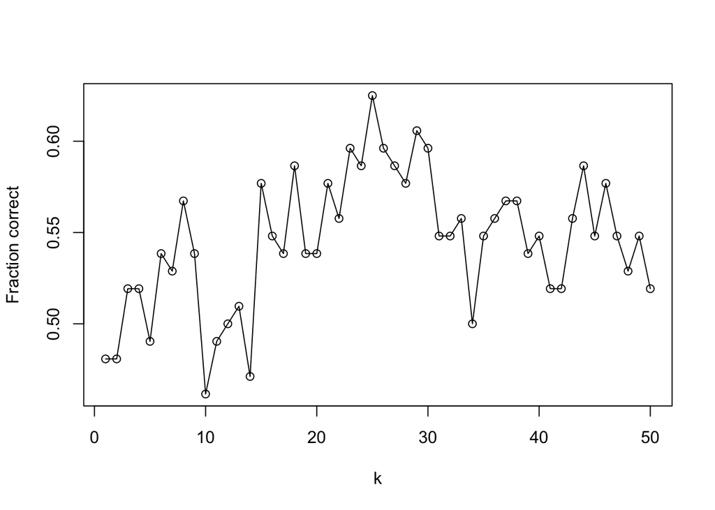

```
[1] "Lag1 to Lag 2 - max correctness is: 0.625"
```

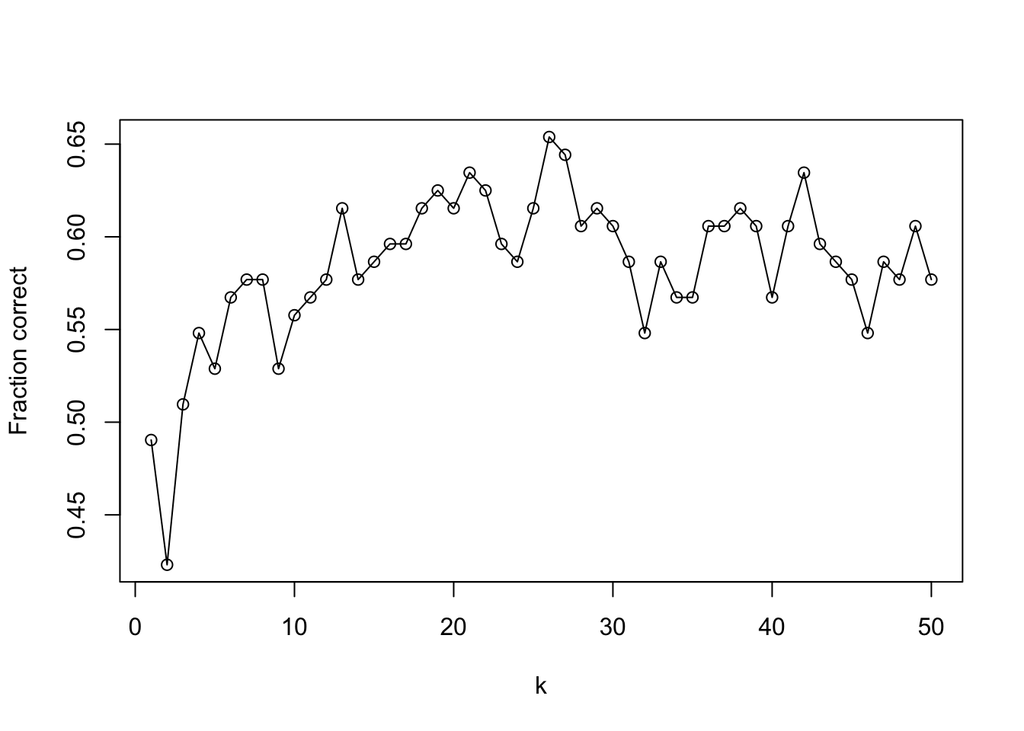

```
[1] "Lag1 to Lag 3 - max correctness is: 0.653846153846154"
```

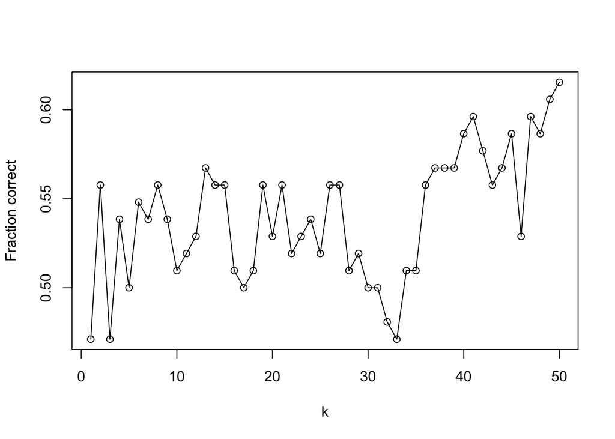

```
[1] "Lag1 to Lag 4 - max correctness is: 0.615384615384615"
```

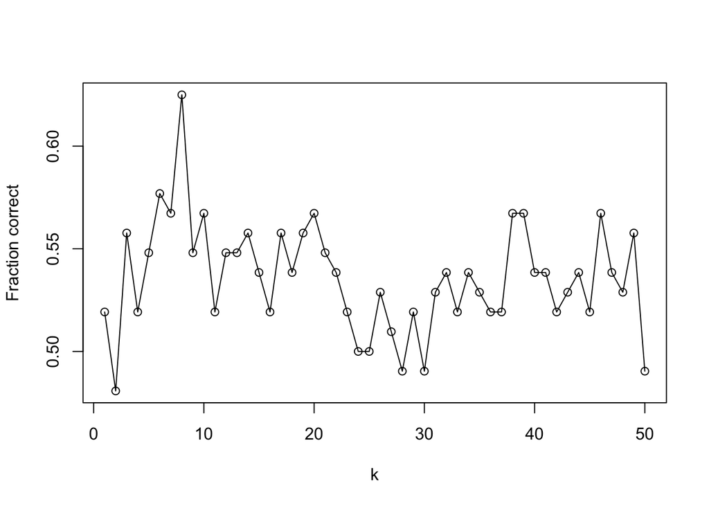

```
[1] "Lag1 to Lag 5 - max correctness is: 0.625"
```

```r
set.seed(123456)
for (i in 3:6){
correctness <- sapply(1:50, function(k) {
  fit_knn_trial <- knn(
    Weekly[training_data, 2:i, drop = FALSE],
    Weekly[!training_data, 2:i, drop = FALSE],
    Weekly$Direction[training_data],
    k = k
  )
  mean(fit_knn_trial == Weekly[!training_data, ]$Direction)
})
plot(1:50, correctness, type = "o", xlab = "k", ylab = "Fraction correct")
print(paste("Lag1 to Lag", i-1, "- max correctness is:", max(correctness)))
}
```

From above result, we know that the first three lag variables are the best. Then we find the best k:

```r
correctness <- sapply(1:50, function(k) {
  fit_knn_trial <- knn(
    Weekly[training_data, 2:4, drop = FALSE],
    Weekly[!training_data, 2:4, drop = FALSE],
    Weekly$Direction[training_data],
    k = k
  )
  mean(fit_knn_trial == Weekly[!training_data, ]$Direction)
})
k <- which.max(correctness)
k
```

```
[1] 22
```

The best k is 22. Then we use the best k to fit the model:

```r
set.seed(123)
fit_knn <- knn(
  Weekly[training_data, 2:4, drop = FALSE],
  Weekly[!training_data, 2:4, drop = FALSE],
  Weekly$Direction[training_data],
  k = k
)
```

Confusion matrix:

```r
t <- table(fit_knn, Weekly[!training_data, ]$Direction)
t
```

```
fit_knn Down Up
   Down   25 20
   Up     18 41
```

Overall fraction of correct predictions:

```r
mean(fit_knn == Weekly[!training_data, ]$Direction)
```

```
[1] 0.6346154
```

```r
sum(diag(t)) / sum(t)
```

```
[1] 0.6346154
```

## 6 Bonus question: ISL Exercise 4.8.4 (30pts)

> When the number of features $p$ is large, there tends to be a deterioration in the performance of KNN and other *local* approaches that perform prediction using only observations that are *near* the test observation for which a prediction must be made. This phenomenon is known as the *curse of dimensionality*, and it ties into the fact that non-parametric approaches often perform poorly when $p$ is large. We will now investigate this curse.
> 1. Suppose that we have a set of observations, each with measurements on $p = 1$ feature, $X$. We assume that $X$ is uniformly (evenly) distributed on $[0, 1]$. Associated with each observation is a response value. Suppose that we wish to predict a test observation’s response using only observations that are within 10% of the range of $X$ closest to that test observation. For instance, in order to predict the response for a test observation with $X = 0.6$, we will use observations in the range $[0.55, 0.65]$. On average, what fraction of the available observations will we use to make the prediction?

**Answer:** For values from $0$ to $0.05$ or from $0.95$ to $1$, we will use less than 10% of observations since there is a boundary, which is between 5% and 10%. Thus, we will calculate it as 7.5% on average for these two parts. For values from $0.05$ to $0.95$ we will use 10% of observations, as no boundary on the two sides. Therefore, The fraction of the available observations on average is
$$7.5percent \times 0.1 + 10percent \times 0.9 = 9.75percent$$
The fraction is 9.75% on average.

> 2. Now suppose that we have a set of observations, each with measurements on $p = 2$ features, $X_1$ and $X_2$. We assume that $(X_1, X_2)$ are uniformly distributed on $[0, 1] \times [0, 1]$. We wish to predict a test observation’s response using only observations that are within 10% of the range of $X_1$ *and* within 10% of the range of $X_2$ closest to that test observation. For instance, in order to predict the response for a test observation with $X_1 = 0.6$ and $X_2 = 0.35$, we will use observations in the range $[0.55, 0.65]$ for $X_1$ and in the range $[0.3, 0.4]$ for $X_2$. On average, what fraction of the available observations will we use to make the prediction?

**Answer:** As the observations are required to be within range for both $X_1$ and $X_2$, we square the fraction of 9.75% as calculated in question (a). Therefore, the result of fraction is $0.0975^2 \times 100 = 0.95\%$

> 3. Now suppose that we have a set of observations on $p = 100$ features. Again the observations are uniformly distributed on each feature, and again each feature ranges in value from 0 to 1. We wish to predict a test observation’s response using observations within the 10% of each feature’s range that is closest to that test observation. What fraction of the available observations will we use to make the prediction?

**Answer:** Similar to our previous process, the fraction for p = 100 is: $0.0975^{100} \times 100 = 8 \times 10^{-100}\%$, which is almost zero.

> 4. Using your answers to parts (a)–(c), argue that a drawback of KNN when $p$ is large is that there are very few training observations “near” any given test observation.

**Answer:** With the increase of $p$, the fraction of the available observations will be decreased rapidly with the exponential speed, even if the range is large.

> 5. Now suppose that we wish to make a prediction for a test observation by creating a $p$-dimensional hypercube centered around the test observation that contains, on average, 10% of the training observations. For $p = 1,2,$ and $100$, what is the length of each side of the hypercube? Comment on your answer.

> *Note: A hypercube is a generalization of a cube to an arbitrary number of* *dimensions. When $p = 1$, a hypercube is simply a line segment, when $p = 2$* *it is a square, and when $p = 100$ it is a 100-dimensional cube.*

**Answer:** When $p = 1$, the length is 0.1. When $p = 2$, we have $l$ which follows $l^2 = 0.1$, so $l = \sqrt{0.1} = 0.32$. When $p = n$, $l = 0.1^{1/n}$, so when $n = 100$, $l = 0.98$. Therefore, the length of each side of the hypercube will approach 1 with the increase of $p$.